# ST3131 Project

# 1 Libraries

```r
library(dplyr);
library(ggplot2);
library(GGally);
library(vioplot);
library(corpcor);
library(ppcor);
library(mctest);
library(ggfortify);
library(lmtest);
library(MASS);
library(car);
library(DAAG);
library(jtools);
library(relaimpo);
```

# 2 Load data

```r
data = read.csv("Admission_Data.csv")
df = data[,2:9]
```

Response variable: Chance.of.Admit Predictors: Everything else

# 3 Descriptive stats

```r
summary(df)
```

```
   GRE.Score      TOEFL.Score    University.Rating      SOP
 Min.   :290.0   Min.   : 92.0   Min.   :1.000     Min.   :1.000
 1st Qu.:308.0   1st Qu.:103.0   1st Qu.:2.000     1st Qu.:2.500
 Median :317.0   Median :107.0   Median :3.000     Median :3.500
 Mean   :316.5   Mean   :107.2   Mean   :3.114     Mean   :3.374
 3rd Qu.:325.0   3rd Qu.:112.0   3rd Qu.:4.000     3rd Qu.:4.000
 Max.   :340.0   Max.   :120.0   Max.   :5.000     Max.   :5.000
      LOR             CGPA          Research    Chance.of.Admit
 Min.   :1.000   Min.   :6.800   Min.   :0.00   Min.   :0.3400
 1st Qu.:3.000   1st Qu.:8.127   1st Qu.:0.00   1st Qu.:0.6300
 Median :3.500   Median :8.560   Median :1.00   Median :0.7200
 Mean   :3.484   Mean   :8.576   Mean   :0.56   Mean   :0.7217
 3rd Qu.:4.000   3rd Qu.:9.040   3rd Qu.:1.00   3rd Qu.:0.8200
 Max.   :5.000   Max.   :9.920   Max.   :1.00   Max.   :0.9700
```

# 4 Distribution plots

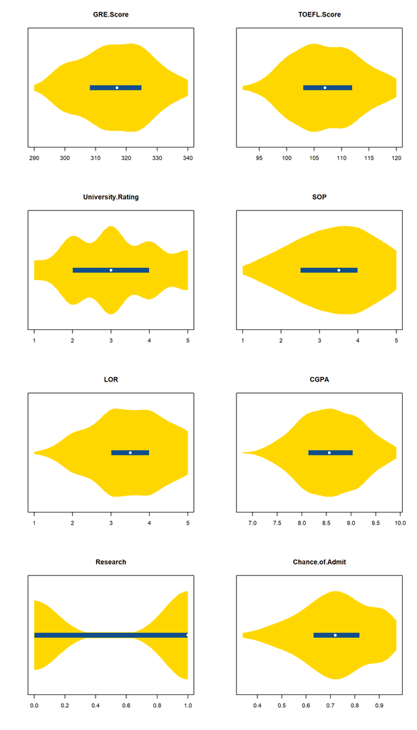

```r
par(mfrow=c(4, 2))
colnames = names(df)
for(name in colnames) {
  vioplot(df[name], horizontal=TRUE, col='gold', lineCol='gold', lty=0, colMed='floralwhite', yaxt='n',rectCol='dodgerblue4')
  title(main=name)
}
```

From our plots, we can see a bell-shape for all variables other than Research, which is a binary variable. This indicates that both predictors and response seem to follow a roughly normal distribution.

There is no extreme skew for the variables. this makes the confidence intervals for estimating parameters for our predictors and estimating the mean response more meaningful.

# 5 Check for 1) Linearity between DV and each of the IVs 2) Multicollinearity between IVs

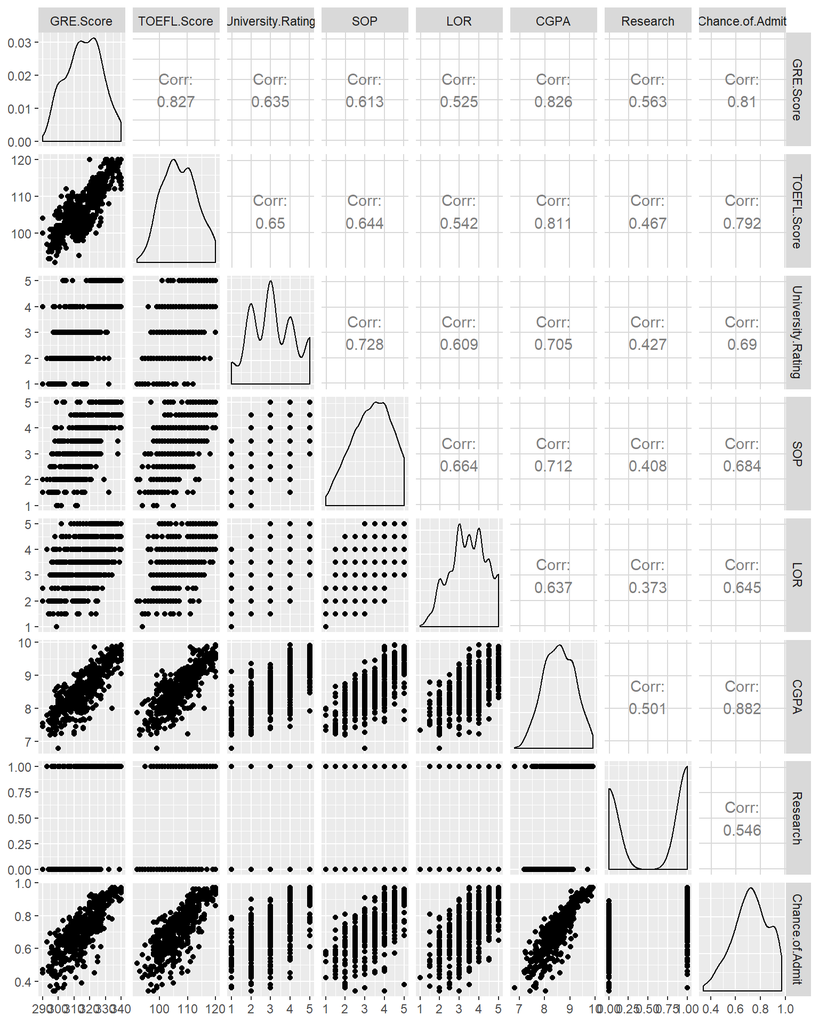

From the last row, we can observe that most of the IVs seem to have a linear relationship with our response variable except for the binary variable Research. Therefore the assumption for linearity between DV and each of IVs hold.

The pairwise correlation for all variables are fairly high. This seems to violate the Multiple Linear Regression’s assumption of No Multicollinearity.

# 6 Partial Correlation coefficients

To account for confounding effects from the other predictors.

```r
pcorr = as.data.frame(cor2pcor(cov(df)))
names(pcorr) = names(df)
rownames(pcorr) = names(df)
pcorr = format(pcorr, digits=1)
print.data.frame(pcorr)
```

```
                  GRE.Score TOEFL.Score University.Rating   SOP   LOR
GRE.Score              1.00        0.43              0.04 -0.03 -0.08
TOEFL.Score            0.43        1.00              0.08  0.09 -0.03
University.Rating      0.04        0.08              1.00  0.37  0.13
SOP                   -0.03        0.09              0.37  1.00  0.29
LOR                   -0.08       -0.03              0.13  0.29  1.00
CGPA                   0.26        0.18              0.09  0.15  0.09
Research               0.25       -0.07              0.04  0.02  0.02
Chance.of.Admit        0.16        0.14              0.07  0.02  0.18
                   CGPA Research Chance.of.Admit
GRE.Score          0.26     0.25            0.16
TOEFL.Score        0.18    -0.07            0.14
University.Rating  0.09     0.04            0.07
SOP                0.15     0.02            0.02
LOR                0.09     0.02            0.18
CGPA               1.00    -0.06            0.48
Research          -0.06     1.00            0.16
Chance.of.Admit    0.48     0.16            1.00
```

The partial correlation coefficients suggest otherwise, that there is less multicollinearity with only GRE.Score & TOEFL.Score having a value > 0.4. Partial correlation between CGPA and our response variable Chance.of.Admit is fairly high but it does not violate the “No Multicollinearity between its IVs assumption” of MLR.

# 7 Using Individual Multicollinearity Diagnostics Measures

```r
imcdiag(df[,1:7],df$Chance.of.Admit)
```

```
Call:
imcdiag(x = df[, 1:7], y = df$Chance.of.Admit)


All Individual Multicollinearity Diagnostics Result

                     VIF    TOL       Wi       Fi Leamer    CVIF Klein
GRE.Score         4.4642 0.2240 284.6458 342.2678 0.4733 -0.2921     0
TOEFL.Score       3.9042 0.2561 238.6295 286.9363 0.5061 -0.2555     0
University.Rating 2.6210 0.3815 133.1951 160.1584 0.6177 -0.1715     0
SOP               2.8352 0.3527 150.7931 181.3188 0.5939 -0.1855     0
LOR               2.0336 0.4917  84.9238 102.1152 0.7012 -0.1331     0
CGPA              4.7780 0.2093 310.4250 373.2656 0.4575 -0.3127     0
Research          1.4940 0.6693  40.5910  48.8080 0.8181 -0.0978     0

1 --> COLLINEARITY is detected by the test
0 --> COLLINEARITY is not detected by the test

University.Rating , SOP , coefficient(s) are non-significant may be due to multicollinearity

R-square of y on all x: 0.8219

* use method argument to check which regressors may be the reason of collinearity
===================================
```

All the predictors have a VIF (=1/(1-R^2)) value of <5 which indicates that the multicollinearity is not so problematic.

# 8 Fitting MLR

```r
fit = lm(Chance.of.Admit ~ ., data=df)
summary(fit)
```

```
Call:
lm(formula = Chance.of.Admit ~ ., data = df)

Residuals:
      Min        1Q    Median        3Q       Max
-0.266657 -0.023327  0.009191  0.033714  0.156818

Coefficients:
                    Estimate Std. Error t value Pr(>|t|)
(Intercept)       -1.2757251  0.1042962 -12.232  < 2e-16 ***
GRE.Score          0.0018585  0.0005023   3.700 0.000240 ***
TOEFL.Score        0.0027780  0.0008724   3.184 0.001544 **
University.Rating  0.0059414  0.0038019   1.563 0.118753
SOP                0.0015861  0.0045627   0.348 0.728263
LOR                0.0168587  0.0041379   4.074 5.38e-05 ***
CGPA               0.1183851  0.0097051  12.198  < 2e-16 ***
Research           0.0243075  0.0066057   3.680 0.000259 ***
---
Signif. codes:  0 '***' 0.001 '**' 0.01 '*' 0.05 '.' 0.1 ' ' 1

Residual standard error: 0.05999 on 492 degrees of freedom
Multiple R-squared:  0.8219,    Adjusted R-squared:  0.8194
F-statistic: 324.4 on 7 and 492 DF,  p-value: < 2.2e-16
```

Fit: Chance.of.Admit = -1.28 + 0.00186(GRE.Score) + 0.00278(TOEFL.Score) + 0.00594(University.Rating) + 0.00159(SOP) + 0.0169(LOR) + 0.118(CGPA) + 0.0243(Research) (3s.f.)

This indicates that on average, a unit increase in GRE.Score/TOEFL.Score/University.Rating/SOP/LOR/CGPA/Research increases Chance.of.Admit by 0.00186/0.00278/0.00594/0.00159/0.0169/0.118/0.0243, while holding all other variables constant.

The p-value for the F-statistic is <2.2e-16, indicating that we can reject the null hypothesis that the intercept-only model is the same fit as the MLR model even at alpha=0.001. Therefore, the MLR model is highly statistically significant at the 0.01 significance level.

The Adjusted R-squared: 0.8194 is high which suggests that the model is a good fit.

The coefficients for GRE.Score, TOEFL.Score, LOR, CGPA, Research are statistically significant at alpha=0.01 where the respective pvalues < 0.01 as we reject the null that their coeffs is 0 at the 0.01 significance level.

The coefficients for University.Rating (0.118) and SOP (0.728263) are >0.01 and we fail to reject the null that their coeffs is 0 at the 0.01 significance level.

# 9 Model diagnostics

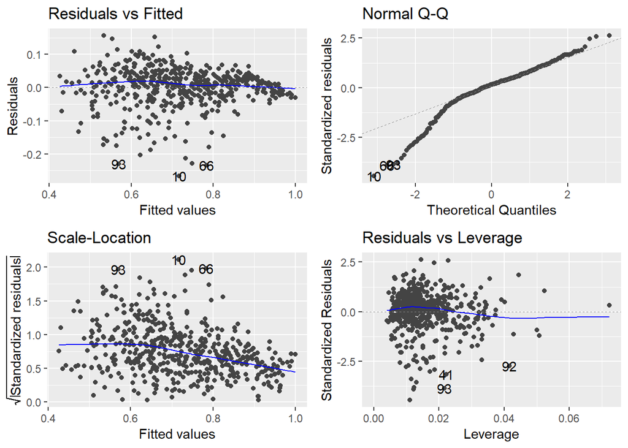

```r
autoplot(fit)
```

1. Residuals vs Fitted The blue line (average value of the residuals at each value of fitted value) is nearly flat. This shows that there is no clear non-linear trend to the residuals. The residuals appear to be randomly spread out, but it converges when near the higher fitted values. This appears to be a decrease in variance and it violates the Homoscedasticity assumption of the MLR.

```r
bptest(fit)
```

```
    studentized Breusch-Pagan test

data:  fit
BP = 30.516, df = 7, p-value = 7.634e-05
```

Using the Breusch-Pagan test to confirm, we can reject the null hypothesis at the 0.05 significance level that variance of the residuals is constant and infer that heteroscedasticity is present. Therefore, this makes our coefficient estimates less precise and increases the likelihood that the estimates are further from the true population value.

2. Normal Q-Q The residuals seem to deviate a lot from the diagonal line in the lower tail. The distribution of residuals is skewed to the left. This suggests that the assumption that of Normality in the Residuals by the MLR model is violated.

Transforming response variable using Box-Cox Power transformation to make it normal and handle heteroscedasticity

```r
bc = boxcox(Chance.of.Admit ~ ., data=df);
```

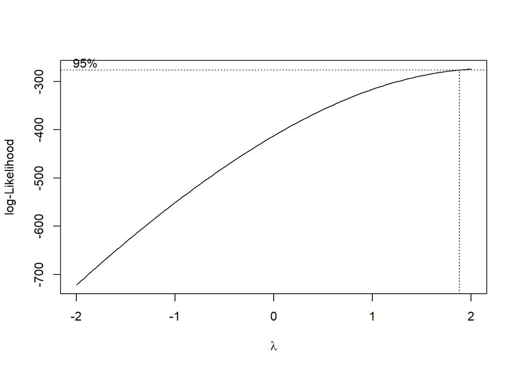

```r
lambda = bc$x[which.max(bc$y)]

powerTransform <- function(y, lambda1, lambda2 = NULL, method = "boxcox") {
  boxcoxTrans <- function(x, lam1, lam2 = NULL) {
    # if we set lambda2 to zero, it becomes the one parameter transformation
    lam2 <- ifelse(is.null(lam2), 0, lam2)
    if (lam1 == 0L) {
      log(y + lam2)
    } else {
      (((y + lam2)^lam1) - 1) / lam1
    }
  }
  switch(method
         , boxcox = boxcoxTrans(y, lambda1, lambda2)
         , tukey = y^lambda1
  )
}


# re-run with transformation
bcfit <- lm(powerTransform(Chance.of.Admit, lambda) ~ ., data=df)
```

The procedure identifies an appropriate exponent (Lambda = l) to use to transform data into a "normal shape. The Lambda value indicates the power to which all data should be raised and it is suggested to use lambda=2.

```r
summary(bcfit)
```

```
Call:
lm(formula = powerTransform(Chance.of.Admit, lambda) ~ ., data = df)

Residuals:
      Min        1Q    Median        3Q       Max
-0.165938 -0.019448  0.006959  0.024234  0.103178

Coefficients:
                    Estimate Std. Error t value Pr(>|t|)
(Intercept)       -1.6494147  0.0677829 -24.334  < 2e-16 ***
GRE.Score          0.0013096  0.0003265   4.011 6.97e-05 ***
TOEFL.Score        0.0021897  0.0005670   3.862 0.000128 ***
University.Rating  0.0064119  0.0024709   2.595 0.009741 **
SOP                0.0018655  0.0029653   0.629 0.529580
LOR                0.0101724  0.0026892   3.783 0.000174 ***
CGPA               0.0814929  0.0063074  12.920  < 2e-16 ***
Research           0.0179019  0.0042931   4.170 3.60e-05 ***
---
Signif. codes:  0 '***' 0.001 '**' 0.01 '*' 0.05 '.' 0.1 ' ' 1

Residual standard error: 0.03899 on 492 degrees of freedom
Multiple R-squared:  0.8493,    Adjusted R-squared:  0.8471
F-statistic: 396.1 on 7 and 492 DF,  p-value: < 2.2e-16
```

The Adjusted R-squared increased from 0.8194 to 0.8471 while the predictors remain significant. However, this model is less interpretable and we want our models to be parsimonious as possible. We will explore more models later on.

3. Residuals vs Leverage This helps us to find influential outliers. They are points above the dashed line which are not approximated well by the model (has high residual) and significantly influences model fit (has high leverage). By considering Cook’s D > 4/sample size criterion, we identify influential outliers to remove.

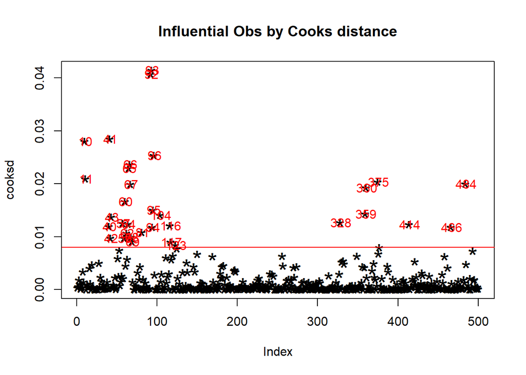

```r
cooksd <- cooks.distance(fit)
sample_size <- nrow(df)
plot(cooksd, pch="*", cex=2, main="Influential Obs by Cooks distance")
abline(h = 4/sample_size, col="red")
text(x=1:length(cooksd)+1, y=cooksd, labels=ifelse(cooksd>4/sample_size, names(cooksd),""), col="red")
```

# 10 Re-fit MLR with outliers removed

```r
influential = as.numeric(names(cooksd)[(cooksd > (4/sample_size))])
df2 = df[-influential, ]
fit2 = lm(Chance.of.Admit ~ ., data=df2)
summary(fit2)
```

```
Call:
lm(formula = Chance.of.Admit ~ ., data = df2)

Residuals:
      Min        1Q    Median        3Q       Max
-0.165185 -0.026028  0.003584  0.027486  0.109968

Coefficients:
                    Estimate Std. Error t value Pr(>|t|)
(Intercept)       -1.2229063  0.0803825 -15.214  < 2e-16 ***
GRE.Score          0.0019839  0.0003834   5.175 3.42e-07 ***
TOEFL.Score        0.0023900  0.0006541   3.654 0.000288 ***
University.Rating  0.0041892  0.0029437   1.423 0.155386
SOP                0.0065602  0.0036266   1.809 0.071120 .
LOR                0.0150463  0.0030929   4.865 1.58e-06 ***
CGPA               0.1128585  0.0075521  14.944  < 2e-16 ***
Research           0.0239311  0.0050812   4.710 3.29e-06 ***
---
Signif. codes:  0 '***' 0.001 '**' 0.01 '*' 0.05 '.' 0.1 ' ' 1

Residual standard error: 0.04367 on 459 degrees of freedom
Multiple R-squared:  0.8932,    Adjusted R-squared:  0.8916
F-statistic: 548.6 on 7 and 459 DF,  p-value: < 2.2e-16
```

By removing the highly influential outliers, we refitted the model on the filtered data and the Adjusted R-squared increased to 0.8194 to 0.8916 without introducing complexity to the model.`

# 11 Fitting the model using a function of the response variable

```r
fit3 = lm(exp(Chance.of.Admit) ~ ., data=df2)
summary(fit3)
```

```
Call:
lm(formula = exp(Chance.of.Admit) ~ ., data = df2)

Residuals:
      Min        1Q    Median        3Q       Max
-0.253893 -0.056622  0.007272  0.055939  0.216996

Coefficients:
                    Estimate Std. Error t value Pr(>|t|)
(Intercept)       -1.9539180  0.1581358 -12.356  < 2e-16 ***
GRE.Score          0.0039627  0.0007542   5.254 2.28e-07 ***
TOEFL.Score        0.0054752  0.0012868   4.255 2.54e-05 ***
University.Rating  0.0131840  0.0057911   2.277   0.0233 *
SOP                0.0118772  0.0071346   1.665   0.0966 .
LOR                0.0281279  0.0060847   4.623 4.93e-06 ***
CGPA               0.2331331  0.0148571  15.692  < 2e-16 ***
Research           0.0495501  0.0099961   4.957 1.01e-06 ***
---
Signif. codes:  0 '***' 0.001 '**' 0.01 '*' 0.05 '.' 0.1 ' ' 1

Residual standard error: 0.08592 on 459 degrees of freedom
Multiple R-squared:  0.9038,    Adjusted R-squared:  0.9023
F-statistic:   616 on 7 and 459 DF,  p-value: < 2.2e-16
```

By regressing the exponent of our response on the predictors, we got an increase in Adjusted R-squared from 0.8916 to 0.9023 while the predictors still remain significnant.

# 12 Accounting for interactions by adding Interaction term

```r
fit4 = lm(exp(Chance.of.Admit) ~ GRE.Score*University.Rating+TOEFL.Score+Research+SOP+LOR+CGPA, data=df2)
summary(fit4)
```

```
Call:
lm(formula = exp(Chance.of.Admit) ~ GRE.Score * University.Rating +
    TOEFL.Score + Research + SOP + LOR + CGPA, data = df2)

Residuals:
      Min        1Q    Median        3Q       Max
-0.254880 -0.051757  0.006082  0.056042  0.217137

Coefficients:
                              Estimate Std. Error t value Pr(>|t|)
(Intercept)                 -0.9107422  0.3463524  -2.630 0.008838 **
GRE.Score                    0.0007173  0.0012168   0.590 0.555800
University.Rating           -0.3143396  0.0971980  -3.234 0.001309 **
TOEFL.Score                  0.0054205  0.0012726   4.259 2.49e-05 ***
Research                     0.0500247  0.0098858   5.060 6.07e-07 ***
SOP                          0.0131953  0.0070659   1.867 0.062478 .
LOR                          0.0288533  0.0060208   4.792 2.23e-06 ***
CGPA                         0.2304806  0.0147127  15.665  < 2e-16 ***
GRE.Score:University.Rating  0.0010313  0.0003055   3.376 0.000799 ***
---
Signif. codes:  0 '***' 0.001 '**' 0.01 '*' 0.05 '.' 0.1 ' ' 1

Residual standard error: 0.08496 on 458 degrees of freedom
Multiple R-squared:  0.9061,    Adjusted R-squared:  0.9045
F-statistic: 552.7 on 8 and 458 DF,  p-value: < 2.2e-16
```

The model shows a signifcant interaction between GRE.Score & University.Rating as the p-value=0.000799 < 0.001 and is significant at the 0.001 significance level.

Interaction arises as the relationship between Chance.of.Admit and the IVs: GRE.Score and University.Rating is affected by the interaction between the GRE.Score & University.Rating. This makes it hard to predict the consequence of changing the value of GRE.Score & University.Rating without controlling for this interaction.

# 13 Comparing nested models with ANOVA

```r
anova(fit3, fit4)
```

|  | Res.Df | RSS | Df | Sum of Sq | F | Pr(>F) |
| --- | --- | --- | --- | --- | --- | --- |
| 1 | 459 | 3.388342 | NA | NA | NA | NA |
| 2 | 458 | 3.306093 | 1 | 0.08224897 | 11.39412 | 0.0007994788 |

The first order model is nested within the interaction model. By using ANOVA to compare the simpler first order model vs the more complex model with interaction term, the p-value=0.0007995 is <0.001. The null hypothesis that the reduced simpler model is adequate is rejected at the 0.001 significance level. Therefore, the complex model did significantly improve the fit over the simpler model.

# 14 Drop insignificant predictor SOP

```r
fit5 = lm(exp(Chance.of.Admit) ~ GRE.Score*University.Rating+TOEFL.Score+Research+LOR+CGPA, data=df2)
summary(fit5)
```

```
Call:
lm(formula = exp(Chance.of.Admit) ~ GRE.Score * University.Rating +
    TOEFL.Score + Research + LOR + CGPA, data = df2)

Residuals:
      Min        1Q    Median        3Q       Max
-0.258558 -0.049296  0.007292  0.055636  0.227183

Coefficients:
                              Estimate Std. Error t value Pr(>|t|)
(Intercept)                 -0.9891596  0.3447277  -2.869  0.00430 **
GRE.Score                    0.0008017  0.0012193   0.658  0.51118
University.Rating           -0.3000927  0.0971603  -3.089  0.00213 **
TOEFL.Score                  0.0056502  0.0012701   4.449 1.08e-05 ***
Research                     0.0498970  0.0099124   5.034 6.92e-07 ***
LOR                          0.0319995  0.0057959   5.521 5.65e-08 ***
CGPA                         0.2360230  0.0144492  16.335  < 2e-16 ***
GRE.Score:University.Rating  0.0009998  0.0003059   3.268  0.00116 **
---
Signif. codes:  0 '***' 0.001 '**' 0.01 '*' 0.05 '.' 0.1 ' ' 1

Residual standard error: 0.08519 on 459 degrees of freedom
Multiple R-squared:  0.9054,    Adjusted R-squared:  0.904
F-statistic: 627.7 on 7 and 459 DF,  p-value: < 2.2e-16
```

Previously, SOP was insignificant at the 0.05 significance level and even after removing it, the model’s Adjusted R-squared is still 0.904.

# 15 Variable selection using stepwise model selection by AIC

```r
step <- stepAIC(fit5, direction="both")
```

```
Start:  AIC=-2292.37
exp(Chance.of.Admit) ~ GRE.Score * University.Rating + TOEFL.Score +
    Research + LOR + CGPA

                              Df Sum of Sq    RSS     AIC
<none>                                     3.3313 -2292.4
- GRE.Score:University.Rating  1   0.07753 3.4088 -2283.6
- TOEFL.Score                  1   0.14364 3.4749 -2274.7
- Research                     1   0.18390 3.5152 -2269.3
- LOR                          1   0.22123 3.5525 -2264.3
- CGPA                         1   1.93650 5.2678 -2080.4
```

```r
step$anova
```

| Step | Df | Deviance | Resid. Df | Resid. Dev | AIC |
| --- | --- | --- | --- | --- | --- |
|  | NA | NA | 459 | 3.331267 | -2292.37 |

A model with fewer parameters is to be preferred to one with more. AIC considers both the fit of the model and the number of parameters used. Having more parameters result in penalty. AIC helps to balance over- and under-fitting. The stepwise model comparison iteratively adds/removes variables one at a time and compares the AIC. The lowest AIC is selected for the final model. In our case, there no further addition or removal of variables required by AIC.

# 16 Relative feature importance

```r
calc.relimp(fit5,type="lmg", rela=TRUE)
```

```
Response variable: exp(Chance.of.Admit)
Total response variance: 0.07558123
Analysis based on 467 observations

7 Regressors:
GRE.Score University.Rating TOEFL.Score Research LOR CGPA GRE.Score:University.Rating
Proportion of variance explained by model: 90.54%
Metrics are normalized to sum to 100% (rela=TRUE).

Relative importance metrics:

                                    lmg
GRE.Score                   0.257942619
University.Rating           0.166817030
TOEFL.Score                 0.156223517
Research                    0.069331682
LOR                         0.096284401
CGPA                        0.250802724
GRE.Score:University.Rating 0.002598027

Average coefficients for different model sizes:

                                    1X        2Xs         3Xs          4Xs
GRE.Score                   0.02074929 0.01423246 0.010334576  0.007621526
University.Rating           0.17676303 0.09256374 0.023688521 -0.058132939
TOEFL.Score                 0.03744779 0.02362103 0.015694761  0.010981393
Research                    0.32556109 0.13545663 0.083229461  0.062005291
LOR                         0.19917859 0.09530881 0.060420345  0.047430322
CGPA                        0.42277371 0.35790428 0.312022662  0.278861853
GRE.Score:University.Rating        NaN        NaN 0.001107569  0.001084120
                                     5Xs          6Xs           7Xs
GRE.Score                    0.005180304  0.002848126  0.0008016795
University.Rating           -0.151442368 -0.237042922 -0.3000927155
TOEFL.Score                  0.008588772  0.007195438  0.0056502353
Research                     0.053312159  0.050658928  0.0498970045
LOR                          0.042830876  0.038606023  0.0319994512
CGPA                         0.258424700  0.246952223  0.2360230300
GRE.Score:University.Rating  0.001057216  0.001028429  0.0009997840
```

GRE.Score 0.257942619 University.Rating 0.166817030 TOEFL.Score 0.156223517 Research 0.069331682 LOR 0.096284401 CGPA 0.250802724 GRE.Score:University.Rating 0.002598027

Relative importance is measured by an algorithm by Lindemann, Merenda and Gold (lmg; 1980) which decomposes total R-squared and observe the increase in R-squared by adding the predictors sequentially. The order of adding predictors matters and therefore, the algorithm takes the average of the R-squared across all orderings.

The features are ranked in this order with highest relative importance first: GRE.Score, CGPA, University.Rating, TOEFL.Score, LOR, Research and GRE.Score*University.Rating.

# 17 K-Fold cross-validation results on final model

```r
cv_new = CVlm(data=df2, fit5, m=3, printit=FALSE)
```

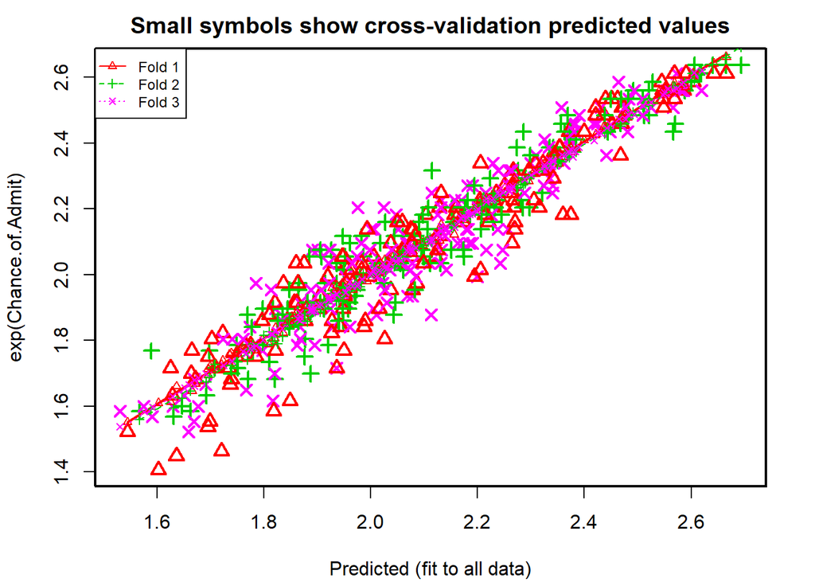

```r
attr(cv_new, "ms")
```

```
[1] 0.007749426
```

Each of the k-fold model’s prediction accuracy isn’t varying too much for any one particular sample, and the lines of best fit from the k-folds don’t vary too much with respect the the slope and level. The average mean square error of the predictions for 3 portions is 0.00775. The value is low and represents a good accuracy result.

# 18 95% CIs for every IV’s estimates

```r
export_summs(fit5, error_format = "[{conf.low}, {conf.high}]", digits=5)
```

|  | Model 1 |
| --- | --- |
| (Intercept) | -0.98916 ** |
|  | [-1.66660, -0.31172] |
| GRE.Score | 0.00080 |
|  | [-0.00159, 0.00320] |
| University.Rating | -0.30009 ** |
|  | [-0.49103, -0.10916] |
| TOEFL.Score | 0.00565 *** |
|  | [0.00315, 0.00815] |
| Research | 0.04990 *** |
|  | [0.03042, 0.06938] |
| LOR | 0.03200 *** |
|  | [0.02061, 0.04339] |
| CGPA | 0.23602 *** |
|  | [0.20763, 0.26442] |
| GRE.Score:University.Rating | 0.00100 ** |
|  | [0.00040, 0.00160] |
| N | 467 |
| R2 | 0.90542 |
| *** p < 0.001; ** p < 0.01; * p < 0.05. |  |

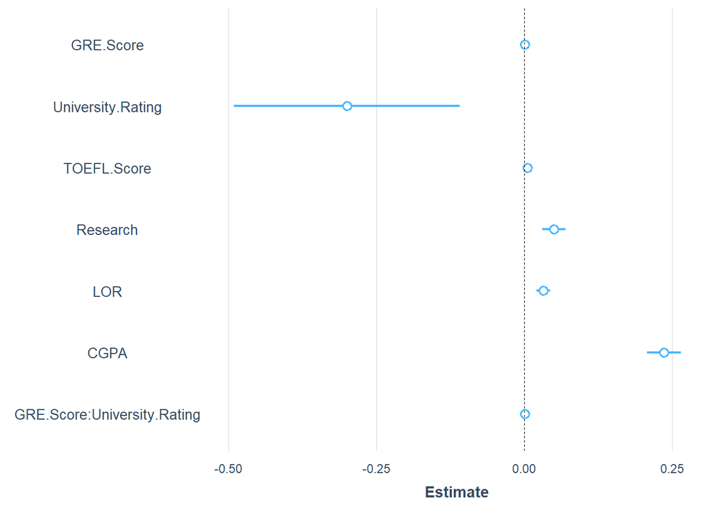

```r
plot_summs(fit5)
```

# 19 Individual CI plots

```
Using data df2 from global environment. This could cause incorrect
results if df2 has been altered since the model was fit. You can
manually provide the data to the "data =" argument.
```

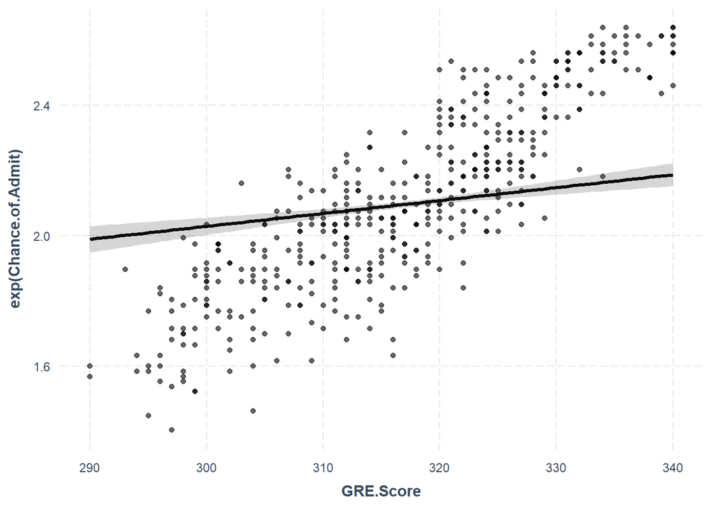

```r
effect_plot(fit4, pred = GRE.Score, interval = TRUE, plot.points = TRUE)
```

```
Using data df2 from global environment. This could cause incorrect
results if df2 has been altered since the model was fit. You can
manually provide the data to the "data =" argument.
```

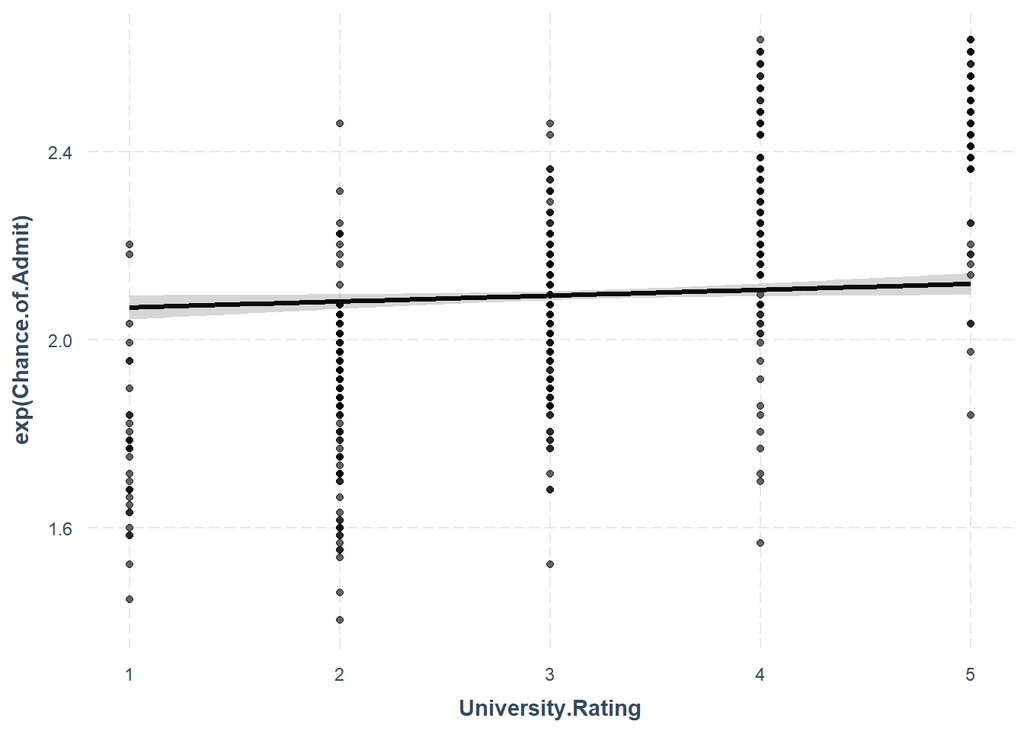

```r
effect_plot(fit4, pred = University.Rating, interval = TRUE, plot.points = TRUE)
```

```
Using data df2 from global environment. This could cause incorrect
results if df2 has been altered since the model was fit. You can
manually provide the data to the "data =" argument.
```

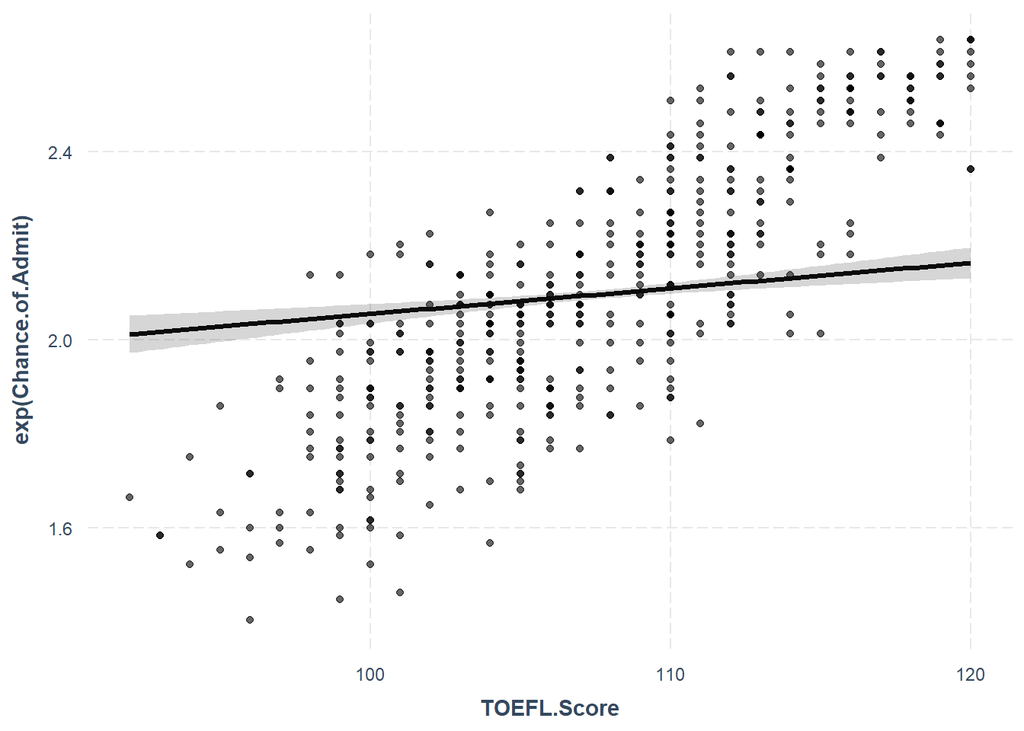

```r
effect_plot(fit4, pred = TOEFL.Score, interval = TRUE, plot.points = TRUE)
```

```
Using data df2 from global environment. This could cause incorrect
results if df2 has been altered since the model was fit. You can
manually provide the data to the "data =" argument.
```

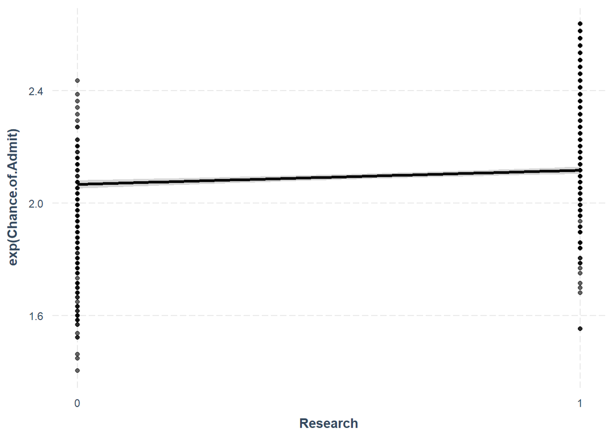

```r
effect_plot(fit4, pred = Research, interval = TRUE, plot.points = TRUE)
```

```
Using data df2 from global environment. This could cause incorrect
results if df2 has been altered since the model was fit. You can
manually provide the data to the "data =" argument.
```

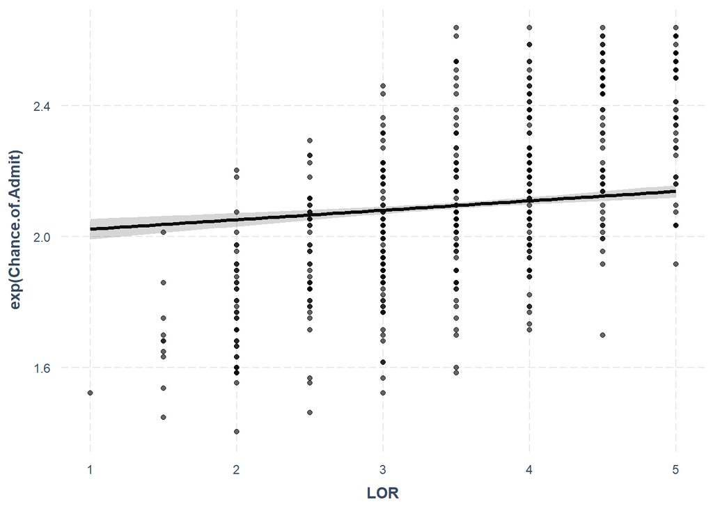

```r
effect_plot(fit4, pred = LOR, interval = TRUE, plot.points = TRUE)
```

```
Using data df2 from global environment. This could cause incorrect
results if df2 has been altered since the model was fit. You can
manually provide the data to the "data =" argument.
```

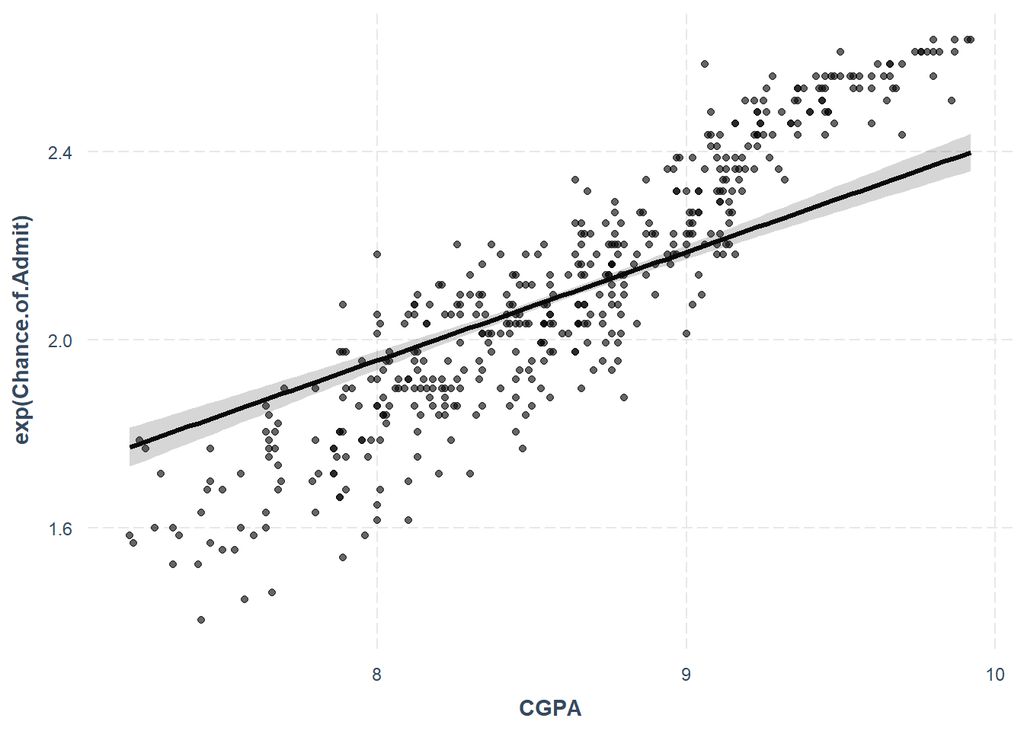

```r
effect_plot(fit4, pred = CGPA, interval = TRUE, plot.points = TRUE)
```

# 20 Final model

```r
summary(fit5)
```

```
Call:
lm(formula = exp(Chance.of.Admit) ~ GRE.Score * University.Rating +
    TOEFL.Score + Research + LOR + CGPA, data = df2)

Residuals:
      Min        1Q    Median        3Q       Max
-0.258558 -0.049296  0.007292  0.055636  0.227183

Coefficients:
                              Estimate Std. Error t value Pr(>|t|)
(Intercept)                 -0.9891596  0.3447277  -2.869  0.00430 **
GRE.Score                    0.0008017  0.0012193   0.658  0.51118
University.Rating           -0.3000927  0.0971603  -3.089  0.00213 **
TOEFL.Score                  0.0056502  0.0012701   4.449 1.08e-05 ***
Research                     0.0498970  0.0099124   5.034 6.92e-07 ***
LOR                          0.0319995  0.0057959   5.521 5.65e-08 ***
CGPA                         0.2360230  0.0144492  16.335  < 2e-16 ***
GRE.Score:University.Rating  0.0009998  0.0003059   3.268  0.00116 **
---
Signif. codes:  0 '***' 0.001 '**' 0.01 '*' 0.05 '.' 0.1 ' ' 1

Residual standard error: 0.08519 on 459 degrees of freedom
Multiple R-squared:  0.9054,    Adjusted R-squared:  0.904
F-statistic: 627.7 on 7 and 459 DF,  p-value: < 2.2e-16
```

Fit: Chance.of.Admit = -0.989 + 0.000802(GRE.Score) -0.300(University.Rating) + 0.00565(TOEFL.Score) + 0.0499(Research) + 0.0320(LOR) + 0.236(CGPA) + 0.00100(GRE.Score*University.Rating) (3s.f.)

This indicates that on average, a unit increase in GRE.Score/University.Rating/TOEFL.Score/Research/LOR/CGPA/GRE.Score*University.Rating increases Chance.of.Admit by 0.000802/-0.300/0.00565/0.0499/0.0320/0.236/0.00100, while holding all other variables constant.

The p-value for the F-statistic is <2.2e-16, indicating that we can reject the null hypothesis that the intercept-only model is the same fit as the MLR model even at alpha=0.001. Therefore, the MLR model is highly statistically significant at the 0.01 significance level.

The Adjusted R-squared: 0.904 is high which suggests that the model is a highly good fit.

The coefficients for all the IVs and the interaction term (except for GRE.Score) are statistically significant at alpha=0.01 where the respective pvalues < 0.01 as we reject the null that their coeffs is 0 at the 0.01 significance level.